# Quality control of somite ATAC-seq data

26 March 2019

We have ATAC-seq data for 75 samples comprising somite trios at six different developmental stages. We have processed the data and retained only good-quality, unique alignments.

```r
## metadata
meta <- read.table(paste0(dir, "ATAC-seq/data/metadata_ATACseq.tsv"), stringsAsFactors = FALSE, header = TRUE)

## BAM files
bam.files <- paste0(dir, "ATAC-seq/data/BWA/", meta$sample, ".noDUPs.GQ.bam")
```

We now need to decide which samples are of enough good quality for downstream analyses.

We can use a number of metrics to assess this, including the insert size distribution (which should show the expected nucleosomal pattern), signal-to-noise ratio inferred from the ability to call peaks and enrichment of signal at the transcription start site (TSS) of genes.

## Insert size distribution

We have analysed the insert size distribution and scored the samples based on the strength of their nucleosomal pattern, from 0 to 4. Two thirds of the samples have a score of 2 or higher, representing samples with a decent to good nucleosomal pattern.

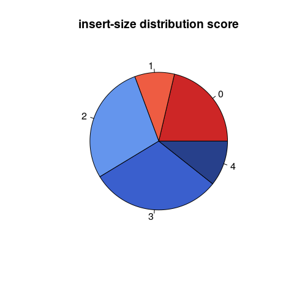

```r
colors <- c("firebrick3", "tomato2", "cornflowerblue", "royalblue3", "royalblue4")
names(colors) <- 0:4
pie(table(meta$insSizeDist), col=colors, main="insert-size distribution score")
```

Luckily, the samples with different scores are spread across stages, showing no systematic biases to a particular time-point. Stage 27 is biased to lower scores but all other stages are pretty balanced.

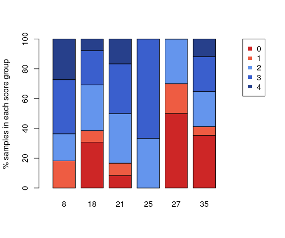

```r
barplot(t(table(meta$stage, meta$insSizeDist)/rowSums(table(meta$stage, meta$insSizeDist)))*100, col=colors, xlim=c(0,7), width = 0.75, space = 0.25, ylab="% samples in each score group")
legend("topright", legend = 0:4, col=colors, pch=15)
```

## Signal-to-noise ratio

Regions of open chromatin should show and enrichment of sequencing fragments and thus appear as *peaks*, or pileups of mapped fragments that are over background noise levels. One way to assess whether such enrichment is present in the data is to call peaks. We have used MACS2 for this, in each individual sample.

Samples with good nucleosomal patterns tend to have higher number of peaks.

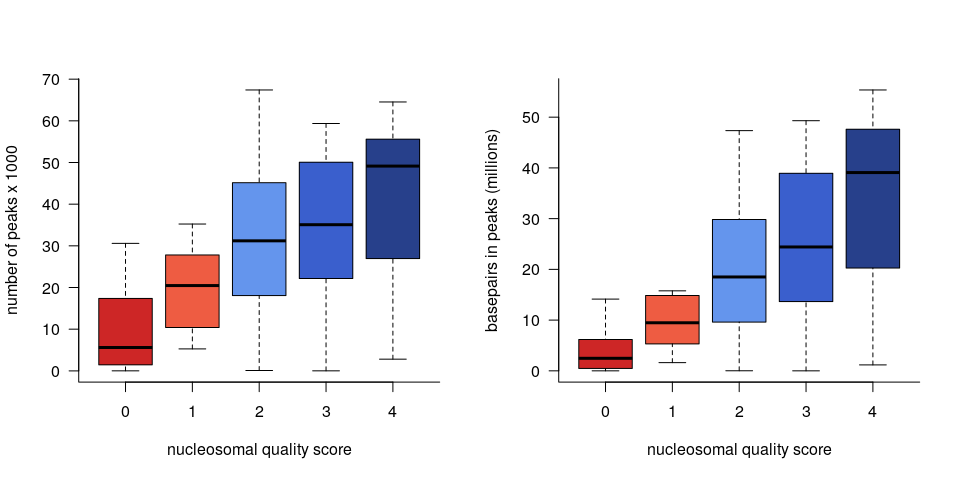

```r
blacklist <- readRDS(paste0(dir, "ATAC-seq/data/mm10-blacklist.v2.Rds"))
peaks <- list()

for(sample in meta$sample){
  peaks[[sample]] <- read.table(paste0(dir, "ATAC-seq/peaks/individualReps/", sample, "_peaks.broadPeak"))[,-6]
  colnames(peaks[[sample]]) <- c("chr", "start", "end", "name", "score", "fc", "pval", "qval")
  peaks[[sample]] <- GRanges(peaks[[sample]]$chr, IRanges(peaks[[sample]]$start, peaks[[sample]]$end), fc=peaks[[sample]]$fc, fdr=peaks[[sample]]$qval, score=peaks[[sample]]$score)
  remove <- unique(queryHits(findOverlaps(peaks[[sample]], blacklist)))
  peaks[[sample]] <- peaks[[sample]][-remove]
}

stopifnot(identical(meta$sample, names(peaks)))
meta$nPeaks <- unlist(lapply(peaks, length))

bpInPeaks <- unlist(lapply(peaks, function(x) sum(width(x))))

par(mfrow=c(1,2))
boxplot(meta$nPeaks/1e3~meta$insSizeDist, col=colors, xlab="nucleosomal quality score", ylab="number of peaks x 1000", axes=FALSE)
box(bty="l"); axis(1, at=1:5, labels=0:4); axis(2, las=2)
boxplot(bpInPeaks/1e6~meta$insSizeDist, col=colors, xlab="nucleosomal quality score", ylab="basepairs in peaks (millions)", axes=FALSE)
box(bty="l"); axis(1, at=1:5, labels=0:4); axis(2, las=2)
```

```r
tmp <- sapply(0:4, function(x) summary(meta[meta$insSizeDist==x,]$nPeaks))
colnames(tmp) <- 0:4
tmp
```

```
##                 0        1        2        3        4
## Min.        6.000  5273.00    81.00     7.00  2811.00
## 1st Qu.  1549.500 10405.00 18073.00 22163.00 27692.50
## Median   5609.000 20477.00 31206.00 35081.00 49137.50
## Mean     9756.812 19632.57 30180.81 34670.43 41338.12
## 3rd Qu. 15469.750 27812.50 45151.00 50070.00 54406.00
## Max.    30594.000 35243.00 67413.00 59371.00 64529.00
```

A cutoff of 15 thousand peaks removes the lowest third of the data.

The *fraction of reads in peaks* is a good measurement of the signal-to-noise ratio. This will of course be correlated to the total number of peaks called.

We use `csaw` to count the number of fragments mapped across called peaks.

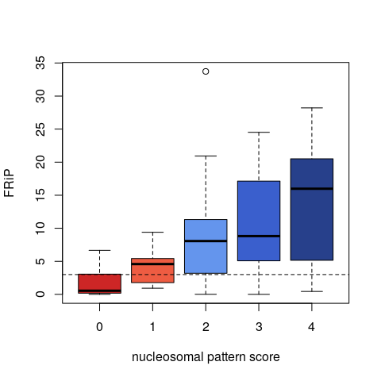

```r
stopifnot(identical(substr(bam.files, 83, nchar(bam.files)-14), names(peaks)))

standard.chr <- paste0("chr", c(1:19, "X")) # restrict analysis to autosomes and the X chr.
param <- readParam(minq=30, discard=blacklist, restrict=standard.chr, pe="both", dedup=FALSE, BPPARAM=MulticoreParam(workers=12))

frip <- list()
for(i in 1:length(bam.files)){
  frip[[i]] <- regionCounts(bam.files[i], peaks[[i]], param = param)
}
names(frip) <- names(peaks)
saveRDS(frip, paste0(dir, "ATAC-seq/results/02_FRiP.Rds"))

frip <- unlist(lapply(frip, function(x) sum(assay(x))))
stopifnot(identical(names(frip), meta$sample))
meta$readsInPeaks <- frip

boxplot(meta$readsInPeaks/meta$goodQuality*100~meta$insSizeDist, col=colors, ylab="FRiP", xlab="nucleosomal pattern score")
abline(h=3, lty=2)
```

Samples with a score of 2 or higher have around 5-25% of reads in peaks. A cutoff of 3% removes the lowest third of the data.

### Reproducibility of peaks

Finally, if the called peaks represent true signal, we should find the same regions in many samples. To confirm this we check how many of the bases covered by one sample’s peaks are also covered in the other samples’ peak calls. Below, each sample is on the x-axis; 1 corresponds to the comparison with itself, and the boxplots indicate the distribution of proportion of overlap with the other 74 samples.

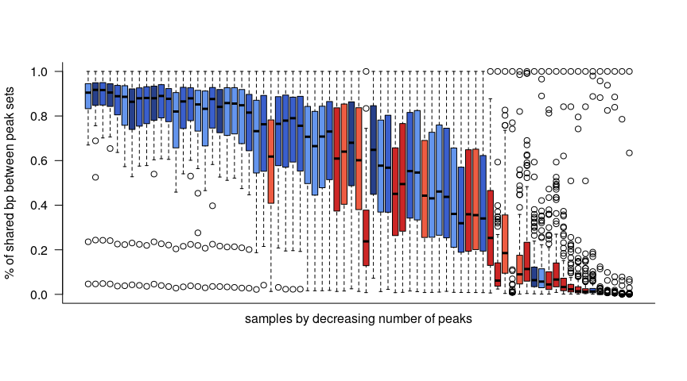

```r
## compute number of bp that overlap between peak sets
peakOverlap <- matrix(ncol=length(peaks), nrow=length(peaks))
for(i in 1:length(peaks)){
  for(j in 1:length(peaks)){
    peakOverlap[i,j] <- sum(width(suppressWarnings(intersect(peaks[[i]], peaks[[j]]))))
  }
}
row.names(peakOverlap) <- names(peaks)
colnames(peakOverlap) <- names(peaks)

## convert into proportion
tmp <- peakOverlap/diag(peakOverlap)  # diagonal contains overlap with itself (i.e. total bp in peaks)

o <- order(meta$nPeaks, decreasing = TRUE)
boxplot(tmp[,o], las=2, col=colors[meta$insSizeDist[o]+1], axes=FALSE, ylab="% of shared bp between peak sets")
box(bty="l"); axis(2, las=2); mtext(side=1, line=0.5, text = "samples by decreasing number of peaks")
```

Overall, samples with scores of 2 or more tend to to have 70-95% of their bases shared with other samples. There are instead a group of samples, predominantly with score of 0 that share very little of their peaks with other samples, suggesting that those peaks are false positives.

## Transcritpion-start site enrichment

```r
## retrieve TSS coordinates for all genes
## we used Ensembl annotation version 96 for the RNA-seq analysis. Use the same for consistentcy.
ensembl <- useMart(host = 'http://apr2019.archive.ensembl.org',
                   biomart = 'ENSEMBL_MART_ENSEMBL', dataset = 'mmusculus_gene_ensembl')

tss <- getBM(attributes=c('ensembl_gene_id', 'external_gene_name', 'chromosome_name', 'transcription_start_site', 'strand'), mart = ensembl)

## retain only expressed genes
expr <- read.table(paste0(dir, "RNA-seq/data/geneCounts.NORM_logCPM.tsv"))
means <- rowMeans(expr[,-1])
# plot(density(means))

keep <- means > log2(10) # use only moderately to highly expressed genes
# summary(keep) # 8025
genes <- names(means[keep])

## keep the earliest TSS for each expressed gene
tss <- tss[tss$ensembl_gene_id %in% genes,]
tmp <- tss[tss$ensembl_gene_id %in% unique(tss[duplicated(tss$ensembl_gene_id),1]),]
tss <- tss[!(tss$ensembl_gene_id %in% unique(tss[duplicated(tss$ensembl_gene_id),1])),]

# for genes in the + strand keep the earliest TSS
tmp.plus <- tmp[tmp$strand==1,]
min <- sapply(unique(tmp.plus$ensembl_gene_id), function(x) min(tmp.plus[tmp.plus$ensembl_gene_id==x,4]))
tmp.plus <- unique(tmp.plus[,1:3])
tmp.plus$transcription_start_site <- min[tmp.plus$ensembl_gene_id]

# for genes in the - strand keep the latest TSS (which is the earliest in the reverse strand)
tmp.minus <- tmp[tmp$strand== -1,]
max <- sapply(unique(tmp.minus$ensembl_gene_id), function(x) max(tmp.minus[tmp.minus$ensembl_gene_id==x,4]))
tmp.minus <- unique(tmp.minus[,1:3])
tmp.minus$transcription_start_site <- max[tmp.minus$ensembl_gene_id]

tss <- rbind(tss[,-ncol(tss)], tmp.minus, tmp.plus)
row.names(tss) <- tss$ensembl_gene_id; tss$ensembl_gene_id <- NULL

## export as BED file (start is 0-based in BED files)
tmp <- data.frame(chr=factor(paste0("chr",tss$chromosome_name), levels=paste0("chr", c(1:19,'X'))), start=tss$transcription_start_site-1001, end=tss$transcription_start_site+1000, gene=tss$external_gene_name, id=row.names(tss))  # providing levels for chromosome allows us to sort in the right order; non-canonical chromosomes become NA
tmp <- tmp[!is.na(tmp$chr),]
tmp <- tmp[order(tmp$chr, tmp$start),]

write.table(tmp, file = paste0(dir, "ATAC-seq/data/TSScoords_expressedGenes_flanking1kb.bed"), quote = FALSE, sep="\t", row.names = FALSE, col.names = FALSE)
```

Using `betools` we can then count the number of Tn5 insertions at each basepair in these 2kb windows (see `ATAC-seq/scripts/dataProcessing/03.0_shiftingReads.md` for details). An insertion is regarded as the 5’ and 3’ ends of a paired-end fragment, after shifting the coordinates to account for the 9bp used by Tn5 for the insertion.

The aggregate profile for all genes gives us a measure of the number of insertions at each basepair, relative to the TSS. We use the first and last 100bp of the 2kb interval as a measurement of the background insertion level, and compute the fold-change of each bp against this. Thus, the flanks should start at 1 and the fold-change should increase if there is an excess of insertions as we approach the TSS.

We indeed see this, with values as high as nearly 10 fold enrichment at the TSS for some samples.

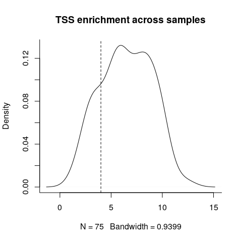

```r
## read insertion counts
tss <- list()
for(sample in meta$sample){
  # print(sample)
  tss[[sample]] <- matrix(read.table(paste0(dir, "ATAC-seq/TSS/", sample, ".TSScount.bed"), stringsAsFactors = FALSE)[,7], ncol = 2001, byrow = TRUE)
}
saveRDS(tss, paste0(dir, "ATAC-seq/results/02_TSSinsertionCounts.Rds"))

## normalise to background
tss.norm <- t(do.call("cbind", lapply(tss, function(x) colMeans(x)/mean(colMeans(x[,c(1:100,1901:2001)])))))

plot(density(tss.norm[,1001]), main="TSS enrichment across samples", bty="l")
abline(v=4, lty=2)
```

Below are the enrichment profiles for each sample, ordered by decreasing number of peaks and coloured by nucleosomal profile score.

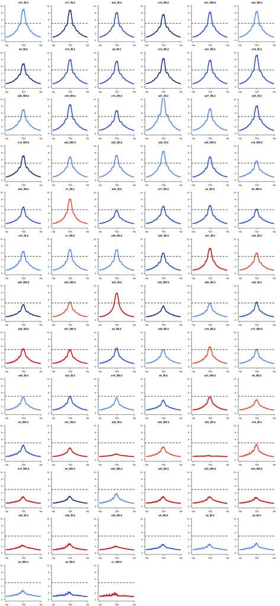

```r
par(mfrow=c(13,6), mar=c(2,2,2,2))
for(sample in meta[order(meta$nPeaks, decreasing = TRUE),]$sample){
  plot(rollmean(tss.norm[sample,], k=25), type="l", lwd=5, main=sample, xlab="", ylab="", col=colors[meta[meta$sample==sample,]$insSizeDist+1], ylim=c(0,10), axes=FALSE)
  box(bty="l"); axis(1, at=c(0,1000,2000), labels = c("-1kb","TSS","1kb")); axis(2,las=2)
  abline(h=5, lty=2, lwd=2)
}

stopifnot(identical(row.names(tss.norm),meta$sample))
meta$TSSscore <- tss.norm[,1001]
```

Again, there is a correlation of good TSS enrichment for samples with high numbers of peaks and good nucleosomal profile, while the bad-quality samples also have very poor TSS enrichment.

As an aside, we observe the greatest enrichment at the TSS, but progressively smaller peaks at ~200bp intervals there on. This reflects the signal coming from nucleosome-bound genes. Above I’ve plotted the aggregate profile of all genes, regardless of strand. If the analysis is split for genes in each strand, mirror profiles occur, with the nucleosomal pattern downstream of the TSS.

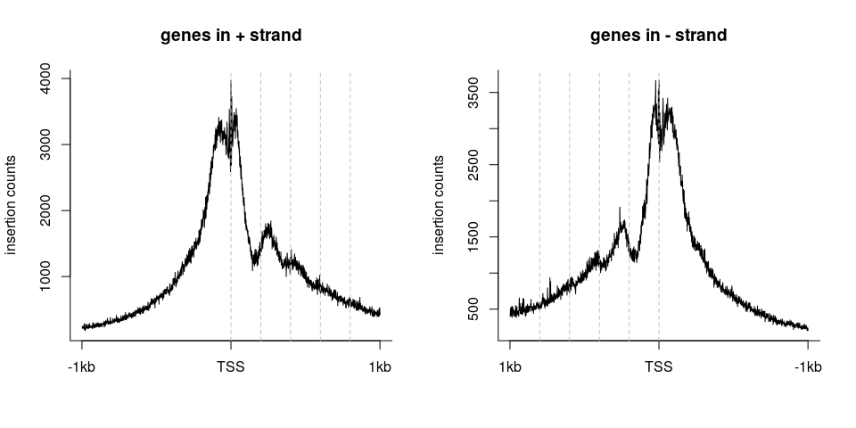

```r
ann <- read.table(paste0(dir, "RNA-seq/data/Mus_musculus.GRCm38.96.ann"), row.names = 1)
tmp <- read.table(paste0(dir, "ATAC-seq/data/TSScoords_expressedGenes_flanking1kb.bed"), stringsAsFactors = FALSE)
strands <- ann[tmp$V5,5]

par(mfrow=c(1,2))
plot(colSums(tss[['e17_SI-2']][strands=="+",]), ylab="insertion counts", xlab="", type="l", axes=FALSE, main="genes in + strand")
box(bty="l"); axis(1, at=c(0,1000,2000), labels = c("-1kb", "TSS", "1kb")); axis(2)
abline(v=seq(1000,1800,200), lty=2, col="grey")
plot(colSums(tss[['e17_SI-2']][strands=="-",]), ylab="insertion counts", xlab="", type="l", axes=FALSE, main="genes in - strand")
box(bty="l"); axis(1, at=c(0,1000,2000), labels = c("1kb", "TSS", "-1kb")); axis(2)
abline(v=seq(200,1000,200), lty=2, col="grey")
```

## Quality control

Together, these different metrics allow us to identify the good samples that have great signal-to-noise ratio; the bad samples that are basically just background noise and need to be discarded; and the decent samples, that sit in between.

And with these criteria, 67% of the samples have 3 or 4 passes.

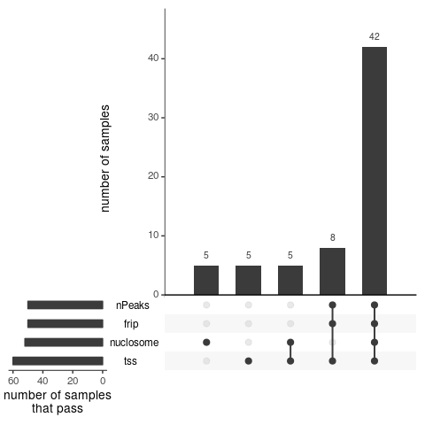

```r
qc <- data.frame(nuclosome = ifelse(meta$insSizeDist>=2, 1, 0), nPeaks = ifelse(meta$nPeaks > 15000, 1, 0), frip = ifelse(meta$readsInPeaks/meta$goodQuality*100 >= 3, 1, 0), tss = ifelse(meta$TSSscore > 4, 1, 0))
row.names(qc) <- meta$sample
# round(table(rowSums(qc))/nrow(qc)*100,2)
# 0     1     2     3     4
# 10    10    5     8     42
# 13.33 13.33  6.67 10.67 56.00

upset(qc, mainbar.y.label = "number of samples", sets.x.label = "number of samples\nthat pass", text.scale=1.25)
```

```r
stopifnot(identical(row.names(qc), meta$sample))
meta$QCpass <- ifelse(rowSums(qc)>2, 1, 0)
table(meta[meta$QCpass==1,]$stage, meta[meta$QCpass==1,]$somite)
```

```
##
##      SI SII SIII
##   8   2   2    2
##   18  3   4    3
##   21  2   4    1
##   25  4   4    3
##   27  3   1    1
##   35  5   4    2
```

```r
write.table(meta, paste0(dir, "ATAC-seq/data/metadata_ATACseq.tsv"), quote = FALSE, sep="\t", row.names = FALSE)
```

Nonetheless, these should be enough samples for a decent analysis.